# Story 4: How Much Do We Get Paid?

Lakeranie Boodram

2026-10-18

## Introduction

Data professionals work in a variety of roles, including Data Scientists, Database Architects, Computer Systems Analysts, and Statisticians. Although these occupations share many responsibilities related to data, their salaries can vary depending on the job title and geographic location.

The purpose of this analysis is to examine how average annual salaries differ among data-related occupations across the United States. Using salary data from the U.S. Bureau of Labor Statistics (BLS), I will compare earnings by occupation and state to identify salary trends and geographic differences.

## Exploring the Dataset

Before analyzing salaries, I examined the dataset to understand its structure, identify the available variables, and determine which columns would be relevant to comparing salaries by occupation and state.

## Data Cleaning and Preparation

To prepare the dataset for analysis, I selected six data-related occupations and focused on the 50 U.S. states and Washington, D.C. I also converted the salary columns into numeric values and removed records without available average salary information. This allows me to compare annual salaries across occupations and geographic locations.

## Salary Comparison by Occupation

To begin the analysis, I compared the average annual salaries of six data-related occupations in New York. This visualization highlights how earnings vary depending on the type of data-related work performed. New York serves as an initial example before expanding the comparison across other states.

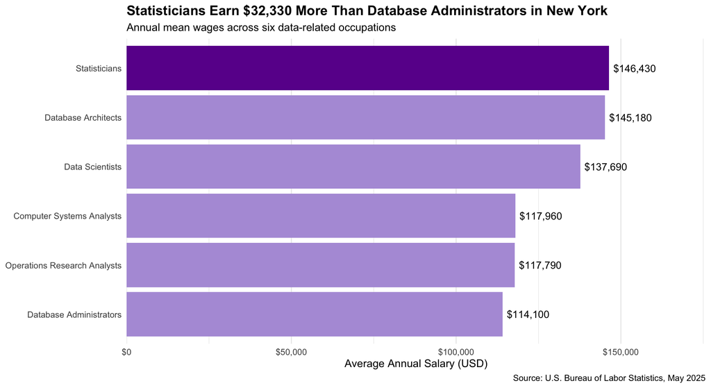

## Geographic Salary Differences Across the United States

In addition to comparing salaries by occupation, I wanted to examine how geographic location affects earnings. For this comparison, I focused on Data Scientists and their average annual salaries across the United States.

The map uses state-level salary data to highlight geographic differences and identify which states offer higher or lower average salaries for this occupation.

[interactive chart not shown]

## Salary Comparison by Occupation and State

To examine salary differences more closely, I created a heatmap comparing the average annual salaries of six data-related occupations across U.S. states. This visualization allows me to identify which occupations offer higher salaries in different geographic locations and whether certain states consistently have higher earnings.

[interactive chart not shown]

*Note: White cells represent occupation and state combinations where salary estimates were unavailable or suppressed in the BLS dataset. These cells should not be interpreted as zero salaries.*

*Source: U.S. Bureau of Labor Statistics, May 2025.*

## Conclusion: Both Occupation and Location Influence Salaries

The analysis shows that salaries among data-related professionals vary based on both occupation and geographic location.

In New York, Statisticians earned an average of $146,430 annually, compared with $114,100 for Database Administrators. This represents a difference of $32,330.

Location also makes a significant difference. Data Scientists in Washington earned an average of $158,040, compared with $79,290 in Mississippi, a difference of $78,750.

When comparing occupations and states together, Database Architects in California had the highest average annual salary in the selected dataset at $175,330.

Overall, these findings demonstrate that both job title and location are important when evaluating salary opportunities in data-related careers.

The analysis is based on May 2025 data from the U.S. Bureau of Labor Statistics. Some salary estimates were unavailable or suppressed, and the comparisons do not account for cost of living, experience, or education.